# Preprocessing with vtreat

# vtreat Introduction

This article is a demonstration the use of the [R](https://cran.r-project.org) vtreat variable preparation package followed by [caret](http://topepo.github.io/caret/index.html) controlled training.

In this example we are going to show what building a predictive model using `vtreat` best practices looks like. This is a simple schematic, not a guide. This document simply shows how small an effort is required to add `vtreat` to your predictive modeling practice.

# Data

Build a model predicting an income level from other demographic features. The data is taken from [here](http://archive.ics.uci.edu/ml/machine-learning-databases/adult/).

```r
# load data
# data from: http://archive.ics.uci.edu/ml/machine-learning-databases/adult/
colnames <- c('age', 'workclass', 'fnlwgt', 'education', 'education-num', 'marital-status', 'occupation',  'relationship',
              'race', 'sex', 'capital-gain', 'capital-loss', 'hours-per-week', 'native-country', 'class')
dTrain <- read.table('./data/adult.data.txt', header = FALSE, sep = ',', strip.white = TRUE,
                     stringsAsFactors = FALSE, na.strings = c('NA', '?', ''))
colnames(dTrain) <- colnames
dTest <- read.table('./data/adult.test.txt', skip = 1, header = FALSE, sep = ',', strip.white = TRUE, stringsAsFactors = FALSE,
                    na.strings = c('NA', '?', ''))
colnames(dTest) <- colnames
```

Use `vtreat` to prepare the data for analysis. The goal of vtreat is to ensure a ready-to-dance data frame in a statistically valid manner. Respecting the test/train split and building our data preparation plan only on the training data (though we do apply it to the test data). This step helps with a huge number of potential problems through automated repairs:

- re-encoding missing values
- dealing with large cardinality categorical variables
- dealing with novel levels
- fixing variable/column names to be “R safe”
- looking for strange column types

A few notes on `vtreat` to help undestand the code below: - **treatments** - objects that encapsulate the transformation process from the original variables to the new “clean” variables. - **xcoreFrame** - scoreFrame which contains columns: - *varName*: name of new variable - *origName*: name of original variable that the variable was derived from (can repeat). - *code*: what time of treatment was performed to create the derived variable (useful for filtering). - *varMoves*: logical TRUE if the variable varied during training; only variables that move will be in the treated frame. - *sig*: linear significance of regression derived variable against a 0/1 indicator target for numeric targets, logistic regression significance otherwise. - *needsSplit*: is the variable a sub model and require out of sample scoring. - **prepare**: Using the optional scaling feature `prepare` which scales and centers all significant variables to mean 0, and slope 1 with respect to y: In other words, it rescales the variables to “y-units”. This is useful for downstream principal components analysis. Note: variables perfectly uncorrelated with y necessarily have slope 0 and can’t be “scaled” to slope 1, however for the same reason these variables will be insignificant and can be pruned by pruneSig.

```r
# define problem
yName <- 'class'
yTarget <- '>50K'
varNames <- setdiff(colnames,yName)

# build variable encoding plan and prepare simulated out of sample
# training fame (cross-frame)
# http://www.win-vector.com/blog/2016/05/vtreat-cross-frames/
system.time({
  cd <- vtreat::mkCrossFrameCExperiment(dTrain, varNames, yName, yTarget)
  scoreFrame <- cd$treatments$scoreFrame
  dTrainTreated <- cd$crossFrame
  # pick our variables
  newVars <- scoreFrame$varName[scoreFrame$sig < 1/nrow(scoreFrame)]
  dTestTreated <- vtreat::prepare(cd$treatments, dTest, pruneSig = NULL, varRestriction = newVars)
})
```

```
##    user  system elapsed
##   32.41    0.02   32.50
```

```r
print(newVars)
```

```
##  [1] "age_clean"
##  [2] "workclass_lev_NA"
##  [3] "workclass_lev_x.Federal.gov"
##  [4] "workclass_lev_x.Local.gov"
##  [5] "workclass_lev_x.Private"
##  [6] "workclass_lev_x.Self.emp.inc"
##  [7] "workclass_lev_x.Self.emp.not.inc"
##  [8] "workclass_lev_x.State.gov"
##  [9] "workclass_catP"
## [10] "workclass_catB"
## [11] "education_lev_x.10th"
## [12] "education_lev_x.11th"
## [13] "education_lev_x.Bachelors"
## [14] "education_lev_x.HS.grad"
## [15] "education_lev_x.Masters"
```

[output cut: 44 more lines]

Train the model. In this case we are using `caret` to tune parameters.

```r
# train our model using caret

  yForm <- as.formula(paste(yName,paste(newVars,collapse=' + '),sep=' ~ '))
  # from: http://topepo.github.io/caret/training.html
  fitControl <- trainControl(method = "cv", number = 3)
  model <- train(yForm, data = dTrainTreated, method = "gbm", trControl = fitControl, verbose = FALSE)
  print(model)
```

```
## Stochastic Gradient Boosting
##
## 32561 samples
##    59 predictor
##     2 classes: '<=50K', '>50K'
##
## No pre-processing
## Resampling: Cross-Validated (3 fold)
## Summary of sample sizes: 21708, 21707, 21707
## Resampling results across tuning parameters:
##
##   interaction.depth  n.trees  Accuracy   Kappa
##   1                   50      0.8483462  0.5112687
##   1                  100      0.8554406  0.5553224
##   1                  150      0.8581125  0.5711671
##   2                   50      0.8564847  0.5609390
##   2                  100      0.8607537  0.5856381
##   2                  150      0.8634563  0.5964306
##   3                   50      0.8600166  0.5798544
##   3                  100      0.8651762  0.6019003
##   3                  150      0.8667732  0.6088925
##
## Tuning parameter 'shrinkage' was held constant at a value of 0.1
##
## Tuning parameter 'n.minobsinnode' was held constant at a value of 10
## Accuracy was used to select the optimal model using  the largest value.
## The final values used for the model were n.trees = 150,
##  interaction.depth = 3, shrinkage = 0.1 and n.minobsinnode = 10.
```

```r
  dTest$pred <- predict(model,newdata=dTestTreated,type='prob')[,yTarget]
```

Finally we take a look at the results on the held-out test data.

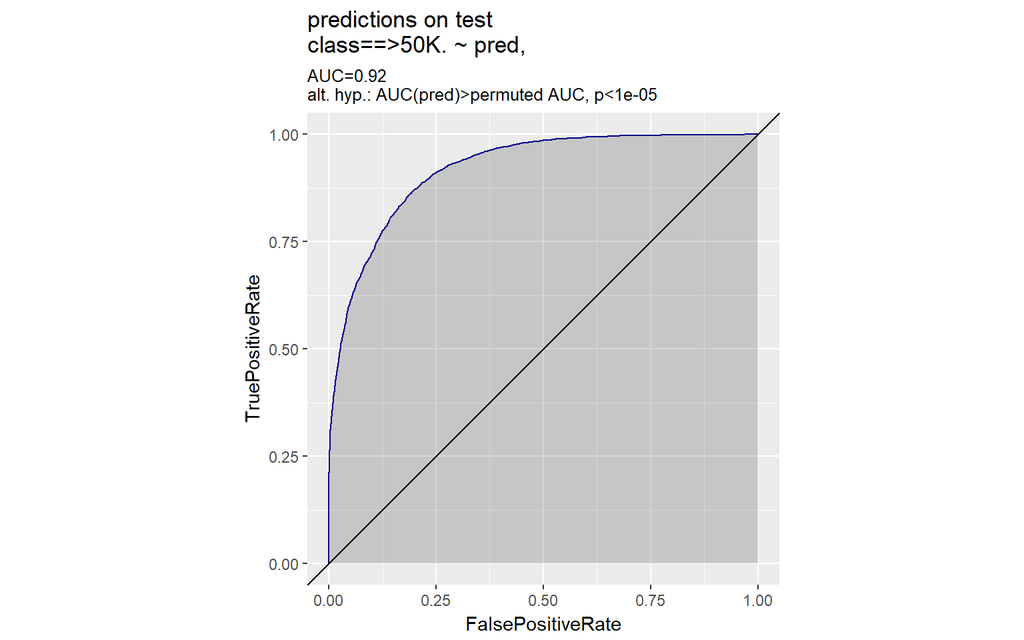

```r
WVPlots::ROCPlot(frame = dTest, xvar = "pred",truthVar = yName, truthTarget = ">50K.", title = "predictions on test")
```

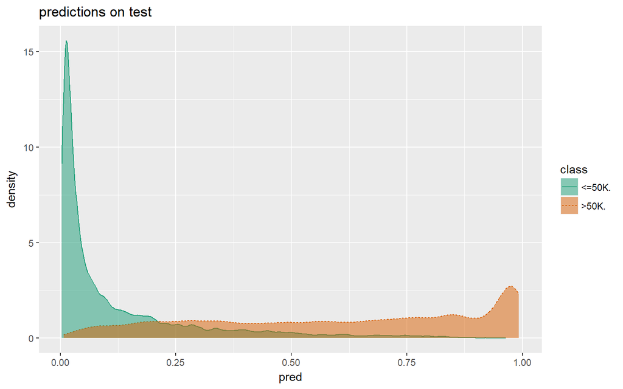

```r
WVPlots::DoubleDensityPlot(dTest, 'pred', yName, 'predictions on test')
```

```r
confusionMatrix <- table(truth = dTest[[yName]], pred = dTest$pred >= 0.5)
print(confusionMatrix)
```

```
##         pred
## truth    FALSE  TRUE
##   <=50K. 11760   675
##   >50K.   1451  2395
```

```r
testAccuarcy <- (confusionMatrix[1, 1] + confusionMatrix[2,2])/sum(confusionMatrix)
testAccuarcy
```

```
## [1] 0.8694183
```

Notice the achieved test accuracy is in the ballpark of what was reported for this dataset.

```
(From http://archive.ics.uci.edu/ml/machine-learning-databases/adult/adult.names )
Error Accuracy reported as follows, after removal of unknowns from
 |    train/test sets):
 |    C4.5       : 84.46+-0.30
 |    Naive-Bayes: 83.88+-0.30
 |    NBTree     : 85.90+-0.28
```

We can also compare accuracy on the “complete cases”:

```r
dTestComplete <- dTest[complete.cases(dTest[,varNames]),]
confusionMatrixComplete <- table(truth=dTestComplete[[yName]], pred=dTestComplete$pred>=0.5)
print(confusionMatrixComplete)
```

```
##         pred
## truth    FALSE  TRUE
##   <=50K. 10694   666
##   >50K.   1377  2323
```

```r
testAccuarcyComplete <- (confusionMatrixComplete[1,1]+confusionMatrixComplete[2,2])/sum(confusionMatrixComplete)
testAccuarcyComplete
```

```
## [1] 0.8643426
```

These two scores are [within noise bounds of each other](http://www.win-vector.com/blog/2015/09/willyourmodelworkpart2/), but it is our experience that missingness is often actually informative, so in addition to imputing missing values you would like to preserve some notation indicating the missingness (which `vtreat` does in fact do).

And that is all there is to this example. I’d like to emphasize that vtreat steps were only a few lines in one of the blocks of code. `vtreat` treatment can take some time, but it is usually bearable. By design it is easy to add vtreat to your predictive analytics projects.

The point is: we got competitive results on real world data, in a single try (using vtreat to prepare data and caret to tune parameters). The job of the data scientist is to actually work longer on a problem and do better. But having a good start helps.

# Referemnce

https://github.com/WinVector/Examples/blob/master/CensusAdultIncomeExample/ExampleRun.Rmd